# Network Performance Anomaly Detection using RIPE Atlas

## Anomaly Detection Methods

Five detectors are applied independently. Each adds an `_anomaly` boolean and a `_score` column to the dataset. A final **ensemble** label flags rows where at least two detectors agree.

### 1 — Z-Score (Statistical Baseline)

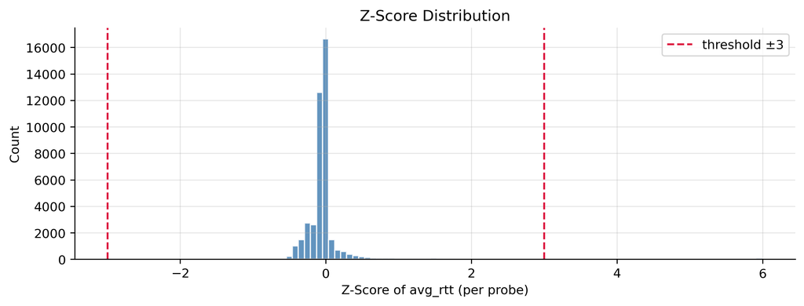

Figure 3: Distribution of per-probe z-scores — values beyond ±3 are flagged

```python
if "z_score_rtt" in df.columns:
    zs = df["z_score_rtt"].dropna()
    fig, ax = plt.subplots(figsize=(9, 3.5))
    ax.hist(zs.clip(-6, 6), bins=80, color="steelblue", edgecolor="white", alpha=0.85)
    ax.axvline(3,  color="crimson", linestyle="--", linewidth=1.5, label="threshold ±3")
    ax.axvline(-3, color="crimson", linestyle="--", linewidth=1.5)
    ax.set_xlabel("Z-Score of avg_rtt (per probe)")
    ax.set_ylabel("Count")
    ax.set_title("Z-Score Distribution")
    ax.legend()
    plt.tight_layout()
    plt.show()
```

### 2 — IQR (Robust Statistical)

Flags measurements outside `[Q1 − 1.5×IQR, Q3 + 1.5×IQR]` computed per probe. Resistant to the extreme skew present in RTT distributions.

### 3 — Isolation Forest (Ensemble ML)

An ensemble of random binary trees. Anomalous points require fewer splits to isolate because they occupy sparse regions of the feature space.

**Features:** `avg_rtt`, `jitter`, `packet_loss_pct`, `rolling_std_rtt`, `hour_of_day`

### 4 — Local Outlier Factor (Density-Based ML)

Compares each point’s local density to its k nearest neighbours (k = 20). Detects local anomalies invisible to global methods — a probe whose RTT doubles relative to its peers is caught even if the absolute value seems normal globally.

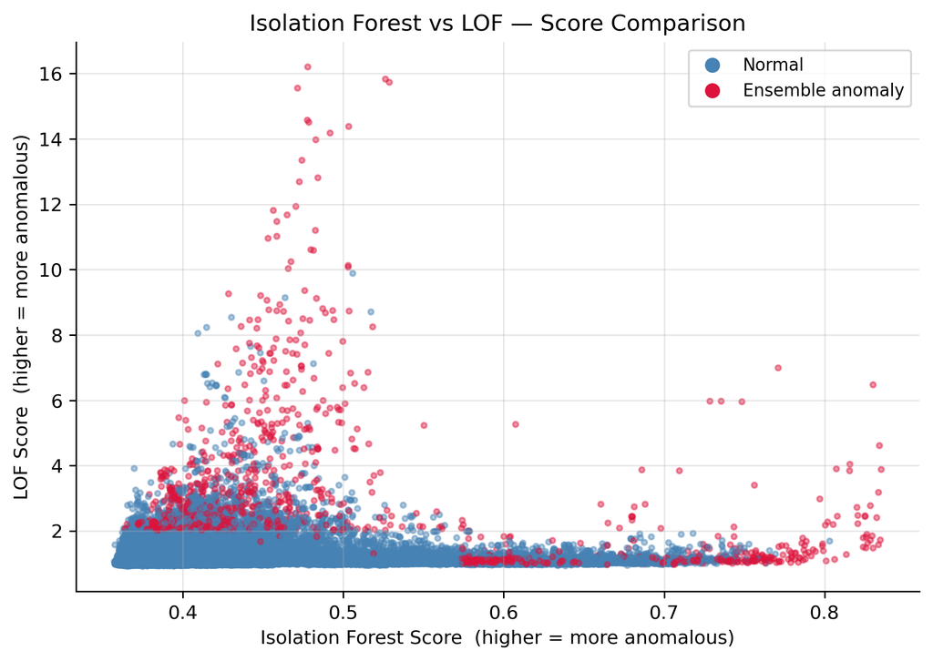

```python
if {"iforest_score", "lof_score", "ensemble_anomaly"}.issubset(df.columns):
    plot_df = df.dropna(subset=["iforest_score", "lof_score"])
    colors   = plot_df["ensemble_anomaly"].map({True: "crimson", False: "steelblue"})

    fig, ax = plt.subplots(figsize=(7, 5))
    ax.scatter(plot_df["iforest_score"], plot_df["lof_score"],
               c=colors, s=8, alpha=0.45)

    from matplotlib.lines import Line2D
    ax.legend(handles=[
        Line2D([0],[0], marker="o", color="w", markerfacecolor="steelblue",
               markersize=9, label="Normal"),
        Line2D([0],[0], marker="o", color="w", markerfacecolor="crimson",
               markersize=9, label="Ensemble anomaly"),
    ], fontsize=9)
    ax.set_xlabel("Isolation Forest Score  (higher = more anomalous)")
    ax.set_ylabel("LOF Score  (higher = more anomalous)")
    ax.set_title("Isolation Forest vs LOF — Score Comparison")
    plt.tight_layout()
    plt.show()
```

## Results

### RTT Time Series with Anomalies

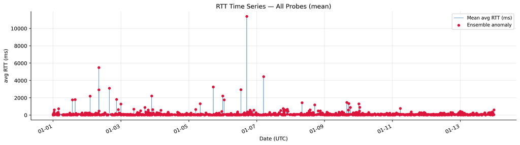

Figure 5: RTT over time (mean across all probes) — red points are ensemble anomalies

```python
agg = (df.groupby("datetime")
         .agg(avg_rtt=("avg_rtt", "mean"),
              anomaly=("ensemble_anomaly", "any"))
         .reset_index())

fig, ax = plt.subplots(figsize=(14, 4))
ax.plot(agg["datetime"], agg["avg_rtt"],
        color="steelblue", linewidth=0.7, label="Mean avg RTT (ms)")
anom = agg[agg["anomaly"]]
ax.scatter(anom["datetime"], anom["avg_rtt"],
           color="crimson", s=18, zorder=5, label="Ensemble anomaly")
ax.xaxis.set_major_formatter(mdates.DateFormatter("%m-%d"))
fig.autofmt_xdate(rotation=25)
ax.set_ylabel("avg RTT (ms)")
ax.set_xlabel("Date (UTC)")
ax.legend(fontsize=9)
ax.set_title("RTT Time Series — All Probes (mean)")
plt.tight_layout()
plt.show()
```

### Anomaly Counts per Detector

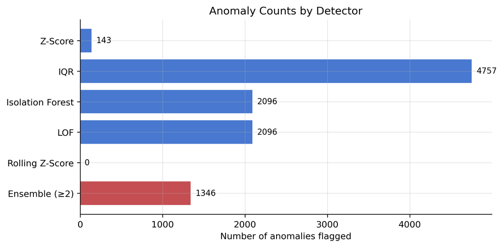

Figure 6: Each detector flags a different volume of anomalies — the ensemble reduces false positives

```python
detector_map = {
    "Z-Score":          "zscore_anomaly",
    "IQR":              "iqr_anomaly",
    "Isolation Forest": "iforest_anomaly",
    "LOF":              "lof_anomaly",
    "Rolling Z-Score":  "rolling_z_anomaly",
    "Ensemble (≥2)":    "ensemble_anomaly",
}
counts = {name: int(df[col].sum())
          for name, col in detector_map.items()
          if col in df.columns}

fig, ax = plt.subplots(figsize=(8, 4))
bars = ax.barh(list(counts.keys()), list(counts.values()),
               color=["#4878cf","#4878cf","#4878cf","#4878cf","#4878cf","#c44e52"],
               edgecolor="white")
ax.bar_label(bars, padding=5, fontsize=9)
ax.invert_yaxis()
ax.set_xlabel("Number of anomalies flagged")
ax.set_title("Anomaly Counts by Detector")
plt.tight_layout()
plt.show()
```

```python
rows = []
for name, col in detector_map.items():
    if col in df.columns:
        n   = int(df[col].sum())
        pct = n / len(df) * 100
        rows.append({"Detector": name, "Anomalies": n, "Rate (%)": round(pct, 2)})

pd.DataFrame(rows).style \
    .background_gradient(subset=["Rate (%)"], cmap="YlOrRd") \
    .hide(axis="index")
```

Table 2: Anomaly detection summary

| Detector | Anomalies | Rate (%) |
| --- | --- | --- |
| Z-Score | 143 | 0.340000 |
| IQR | 4757 | 11.350000 |
| Isolation Forest | 2096 | 5.000000 |
| LOF | 2096 | 5.000000 |
| Rolling Z-Score | 0 | 0.000000 |
| Ensemble (≥2) | 1346 | 3.210000 |